# Make the World Dance

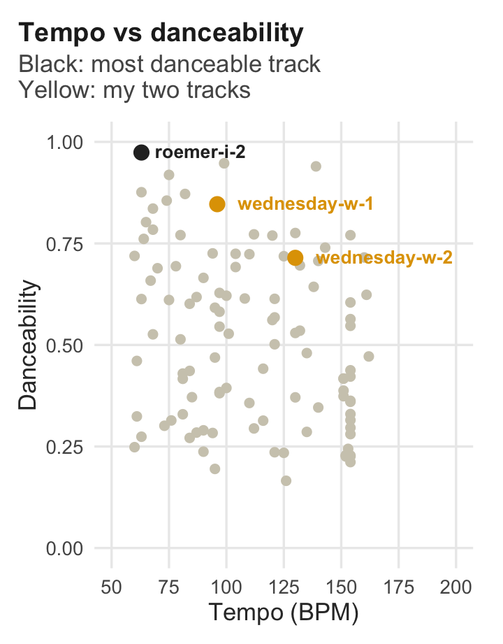

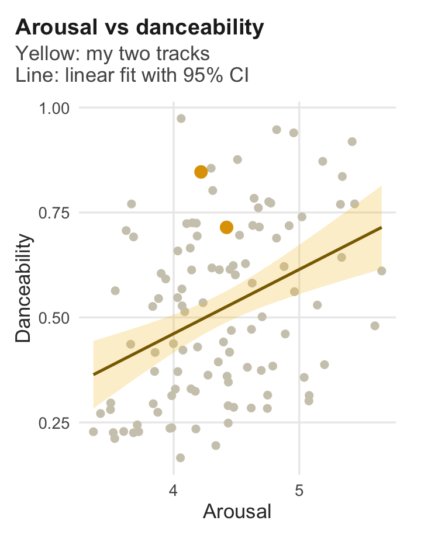

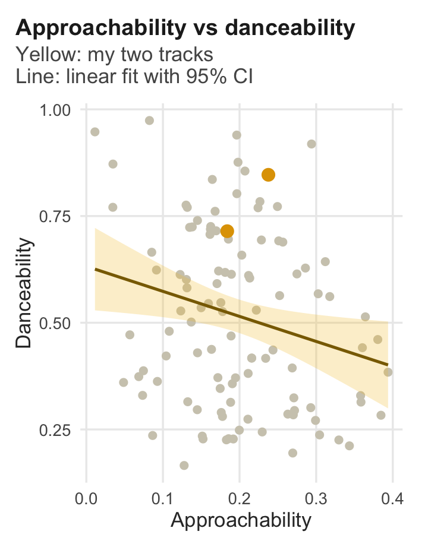

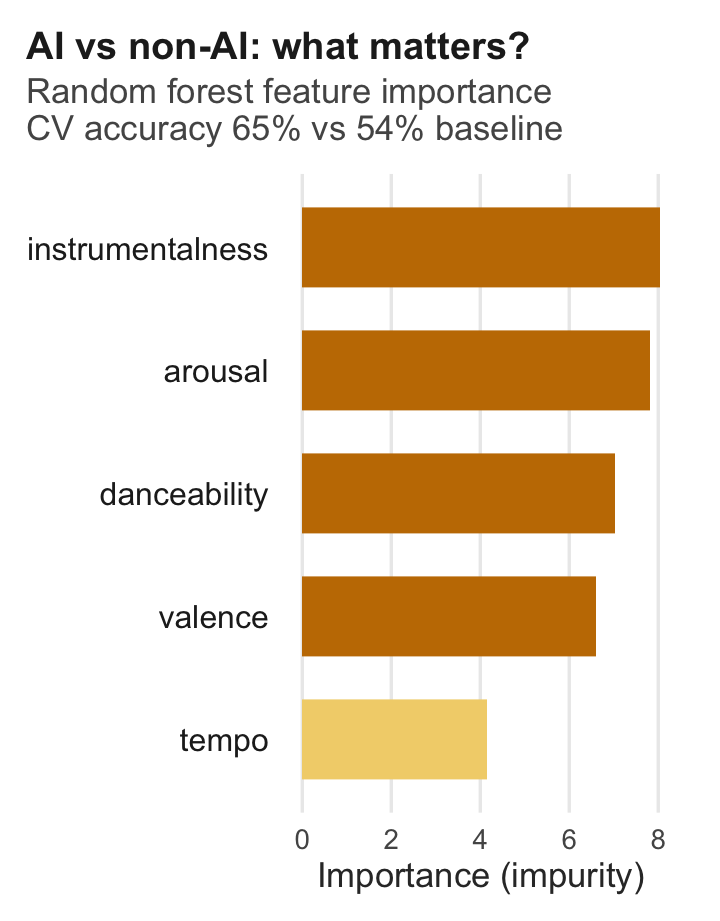

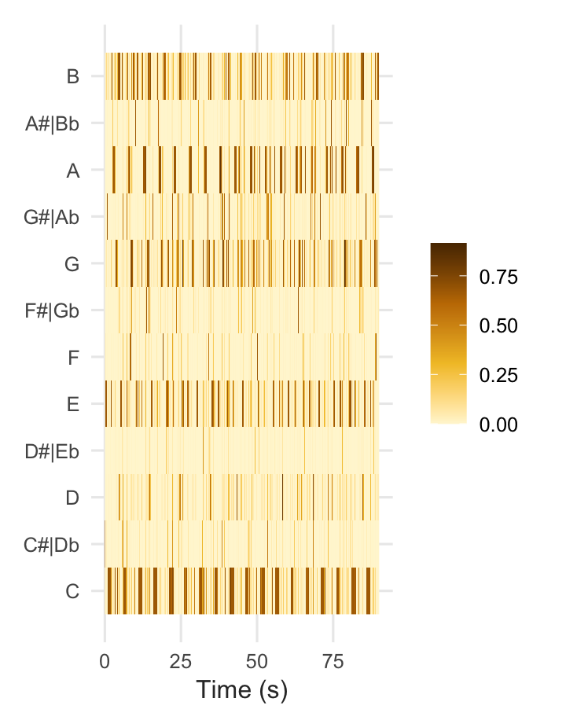

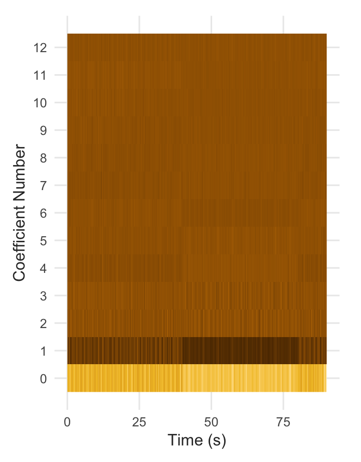

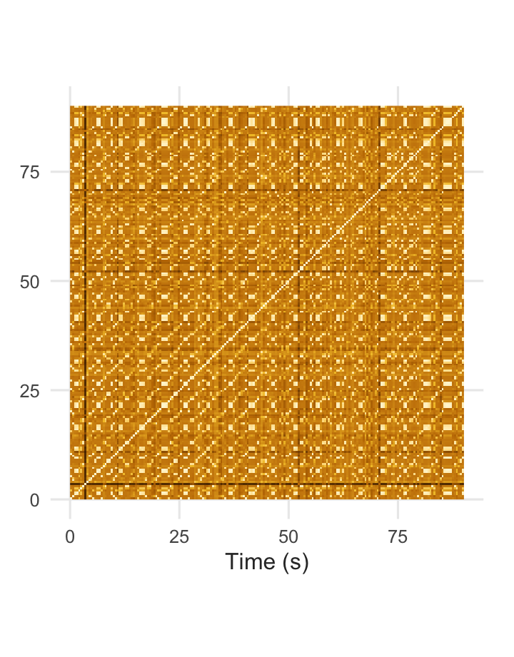

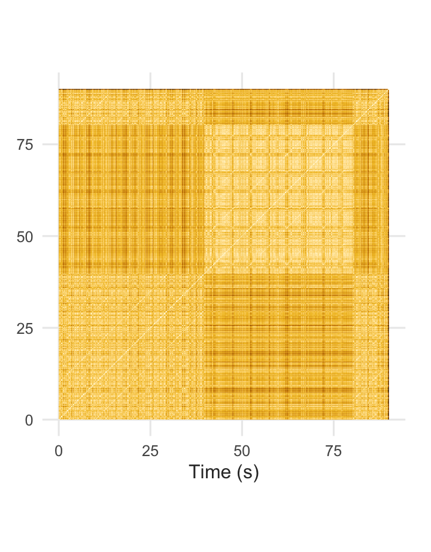

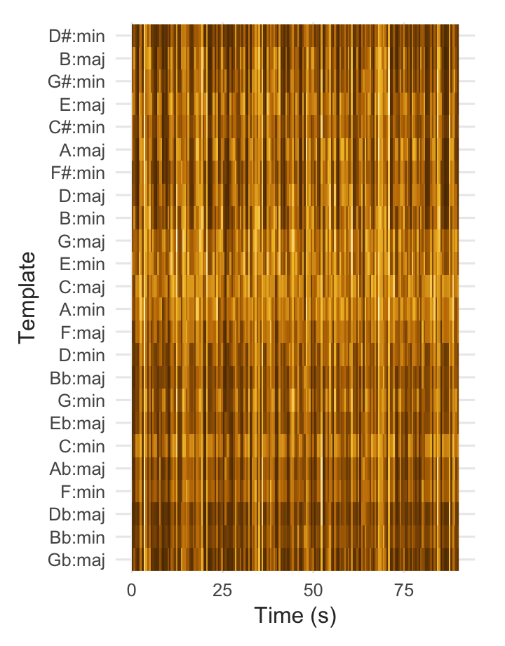

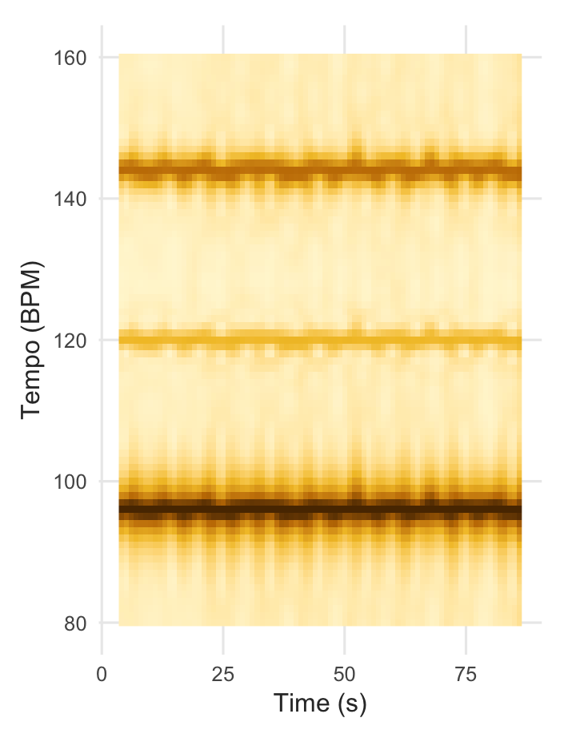

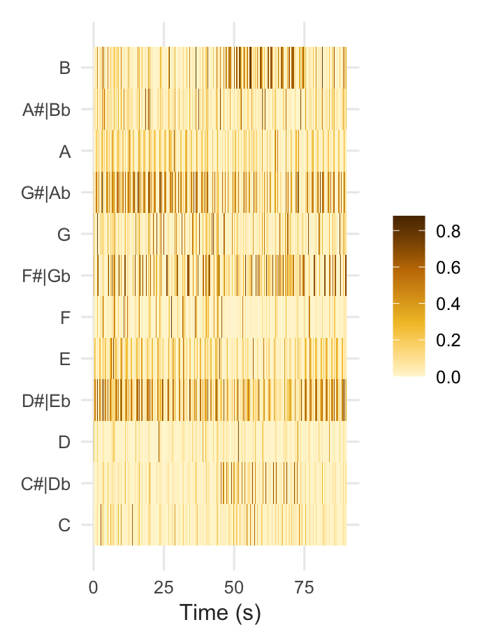

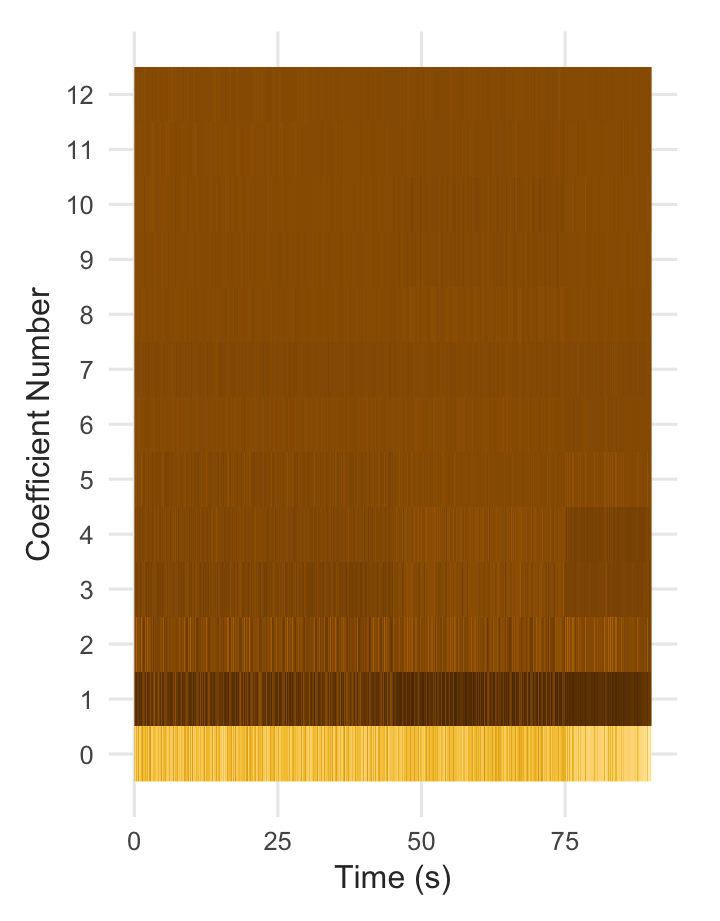

[5 more figures not shown]

# Introduction

### About this project

#### Research question

What makes a piece of music danceable, and could a calm or melancholic track be turned into a danceable one by changing specific features?

#### Data

The tracks come from AIVA’s Styles Library, a collection of tracks generated by an AI model trained in music composition. My two tracks (wednesday-w-1 and wednesday-w-2) are compared against the class corpus of 108 tracks on features such as danceability, arousal, valence, tempo and instrumentalness.

#### Why these tracks

I was particularly drawn to their groove, rhythmic patterns and danceable energy, which made them a good starting point for asking what drives danceability.

#### Approach

1. **Corpus level:** compare the most and least danceable tracks, test simple hypotheses (tempo, arousal, approachability), and train a random forest to tell AI-generated from non-AI tracks.
2. **Track level:** look at mid-level structure in my own tracks (chromagrams, cepstrograms, self-similarity matrices, chordograms, tempograms).

### Top 5 vs bottom 5 tracks by danceability (standardised features)

[interactive chart not shown]

> Using a heatmap, I compared the top 5 most danceable tracks and the bottom 5 least danceable ones to identify distinguishing features. Surprisingly, I found that higher danceability was more associated with high arousal and valence, but not necessarily with higher tempo. In contrast, the least danceable tracks tended to have very high instrumentalness and tempo, but scored low on emotional expressiveness (low valence and arousal). This challenges the common assumption that faster music is always more danceable. Instead, emotional intensity and presence of vocals might matter more. Because this finding was counter-intuitive, I wanted to further explore why some tracks feel more danceable even if they’re slower, so I shifted from corpus-level to track-level analysis.

# Corpus-Level Analysis

### Hypothesis 1: Tempo → Danceability

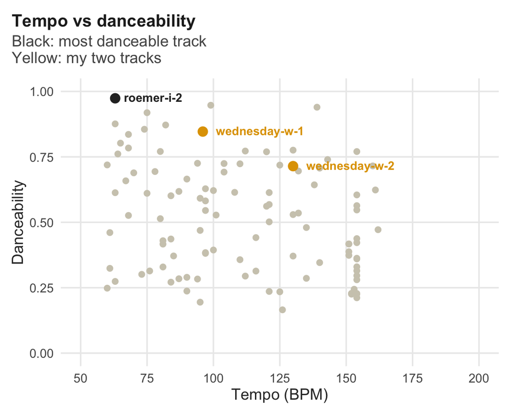

> **Thinking:**  
> Compared to the full dataset, my selected tracks (wednesday-w-1 and wednesday-w-2) exhibit above-average danceability, indicating a strong groove and rhythmic presence. However, they are not the most danceable—that distinction belongs to roemer-i-2, which sits at the top of the chart. Interestingly, although my tracks have a higher tempo, they are still outperformed in danceability. This suggests that tempo alone does not determine how danceable a track feels. There might be other influential features at play, such as engagingness, valence, or instrumental texture.

### Hypothesis 2: Arousal → Danceability

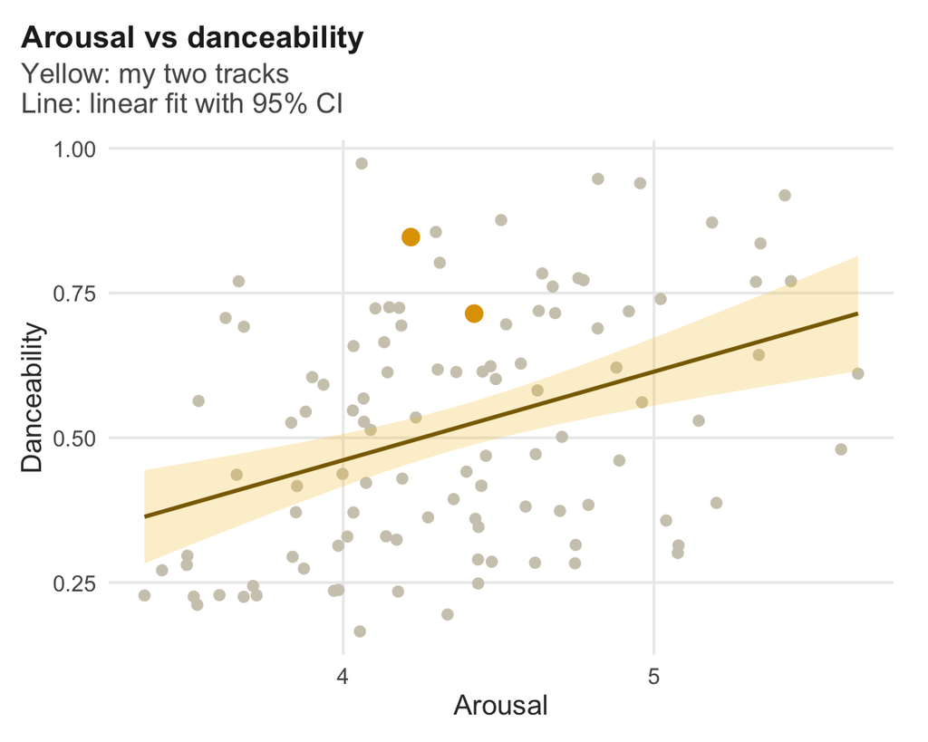

### Hypothesis 3: Approachability → Danceability

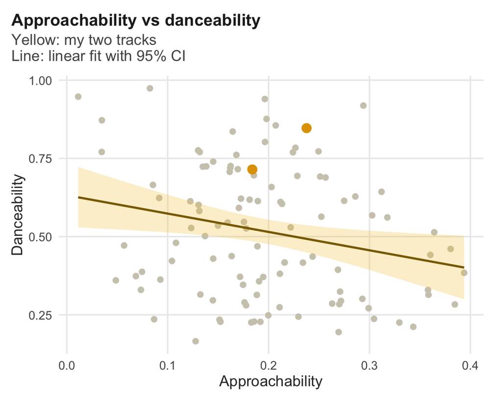

### Classification: AI vs non-AI

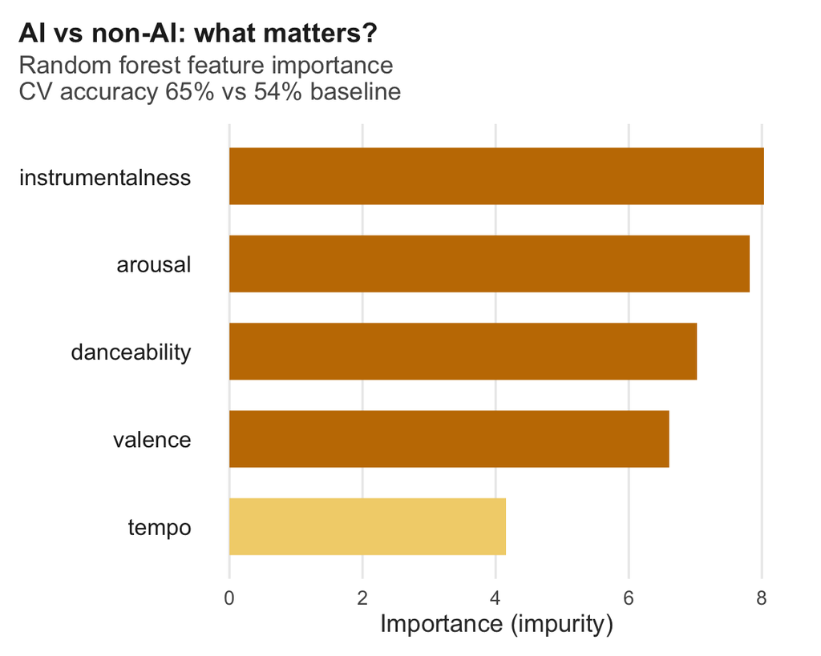

> **Thinking:**  
> To see whether these features also carry information about how a track was made, I trained a random forest (500 trees) to tell AI-generated tracks (n = 49) from non-AI tracks (n = 41). Across 20 repetitions of 5-fold cross-validation it reached an average accuracy of **65%** (range 59–70%), compared with a 54% baseline from always predicting the larger class. The features therefore carry some, but limited, information about whether a track is AI-generated. The model relies most on instrumentalness and arousal, while **tempo is again the least informative feature**, consistent with the danceability results.

# Track-Level Analysis

### Track 1: Chromagram

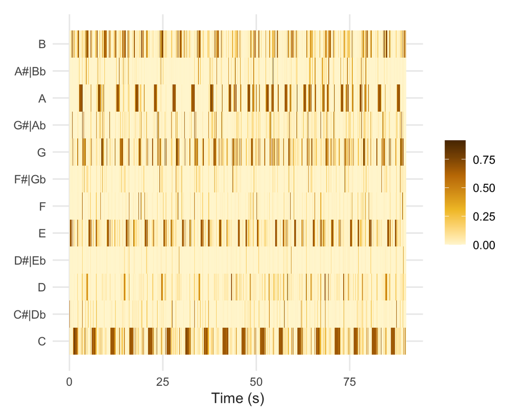

> This track exhibits clear harmonic repetition, with strong vertical striping indicating repeated pitch patterns. This kind of structure is closely related to groove and may contribute to its danceability.

### Cepstrogram

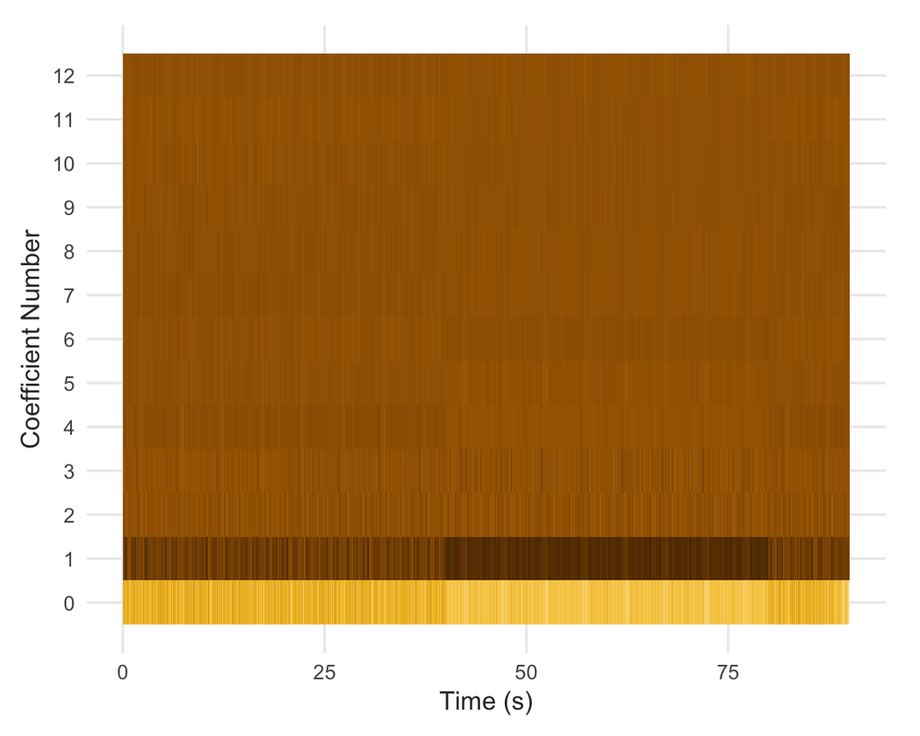

> Track 1 shows stable timbral energy concentrated in lower MFCC coefficients, suggesting a consistent and smooth sonic texture that supports groove.

### Chroma-based

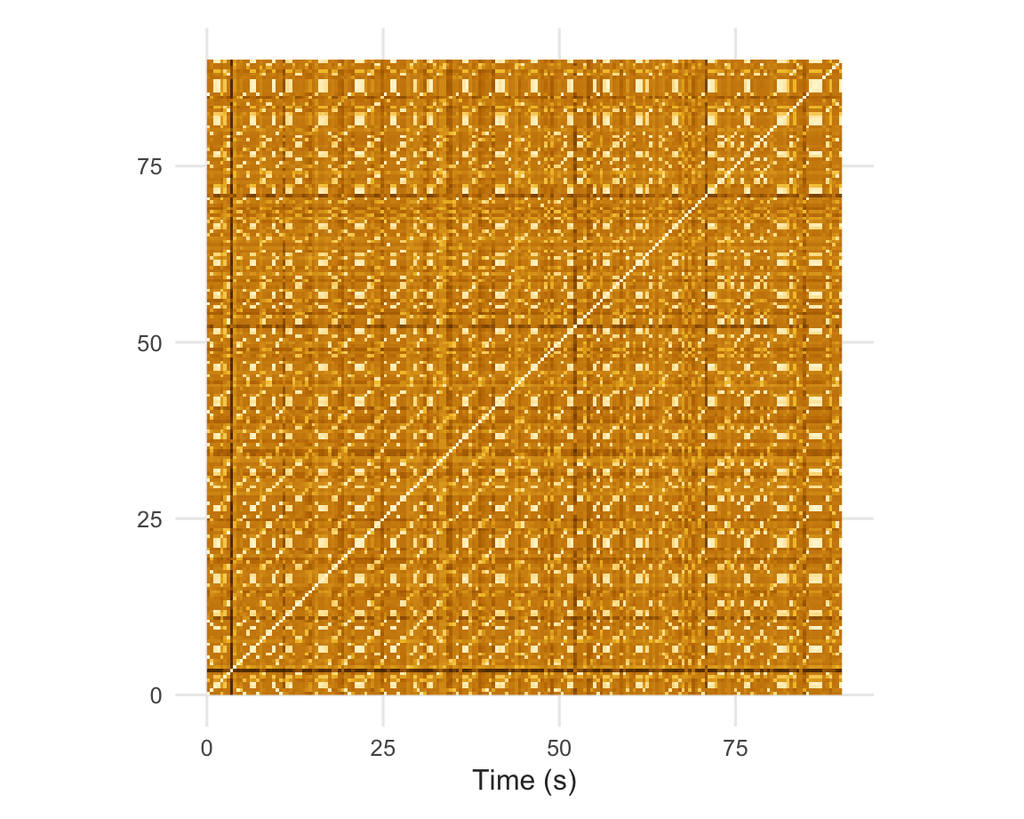

> Track 1 reveals a highly regular harmonic structure, as shown by the dense and symmetrical grid-like patterns in its chroma-based self-similarity matrix. This indicates strong harmonic repetition—such as loops or consistent chord progressions—which may support the feeling of groove and enhance danceability.

### Timbre-based

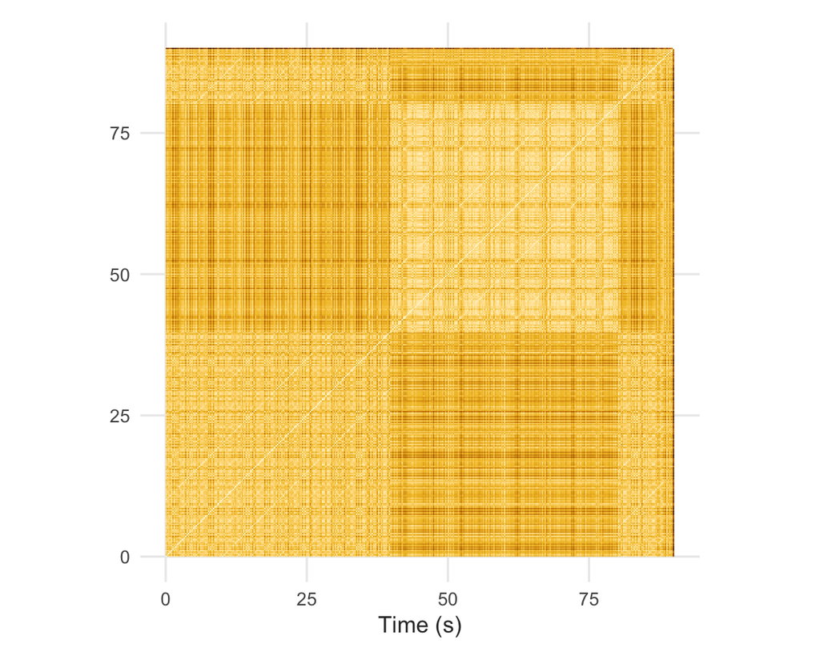

> Track 1 shows clear sectional structure in its timbre-based self-similarity matrix, with large, cohesive blocks indicating repeated segments. These repeating timbral sections likely reflect a structured form (e.g., A–B–A–C), enhancing rhythmic predictability and supporting groove and danceability.

### Chordogram

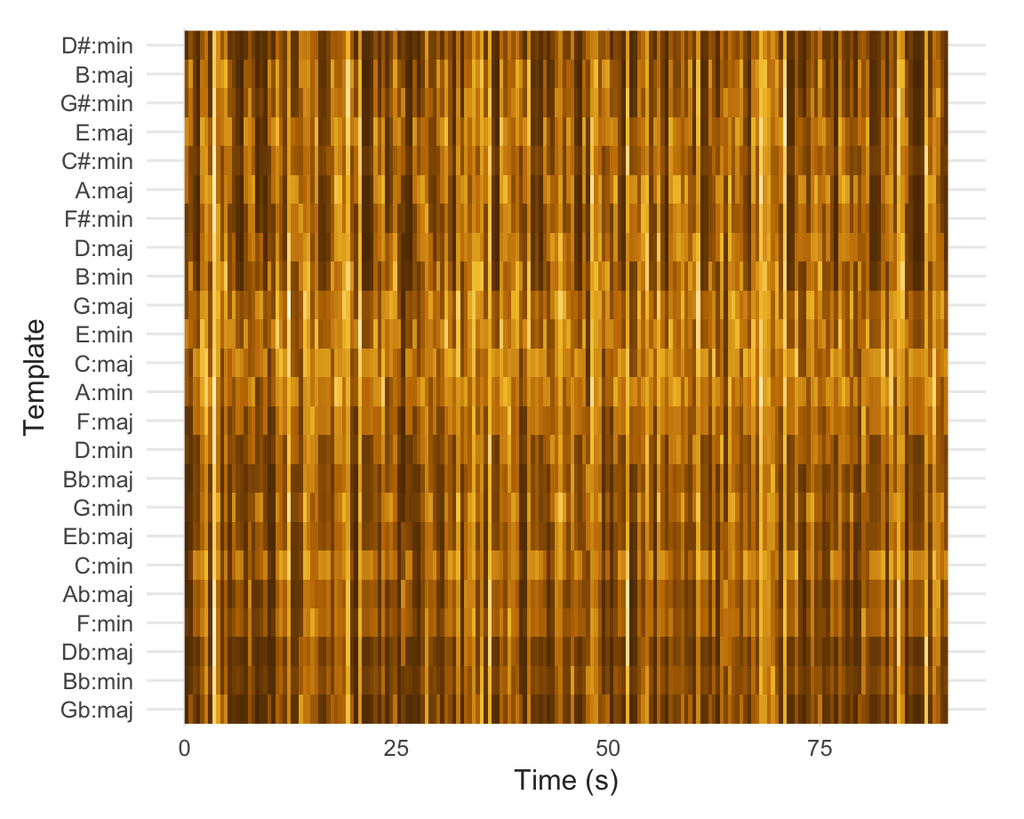

> In Track 1, we observe a highly dense and noisy chordogram, with no clear dominant chords over time. This suggests that the harmonic structure is either highly chromatic, constantly shifting, or contains frequent modulations. Such harmonic richness may contribute to expressiveness but may not strongly support predictability or groove — key components of danceability.

### Tempogram

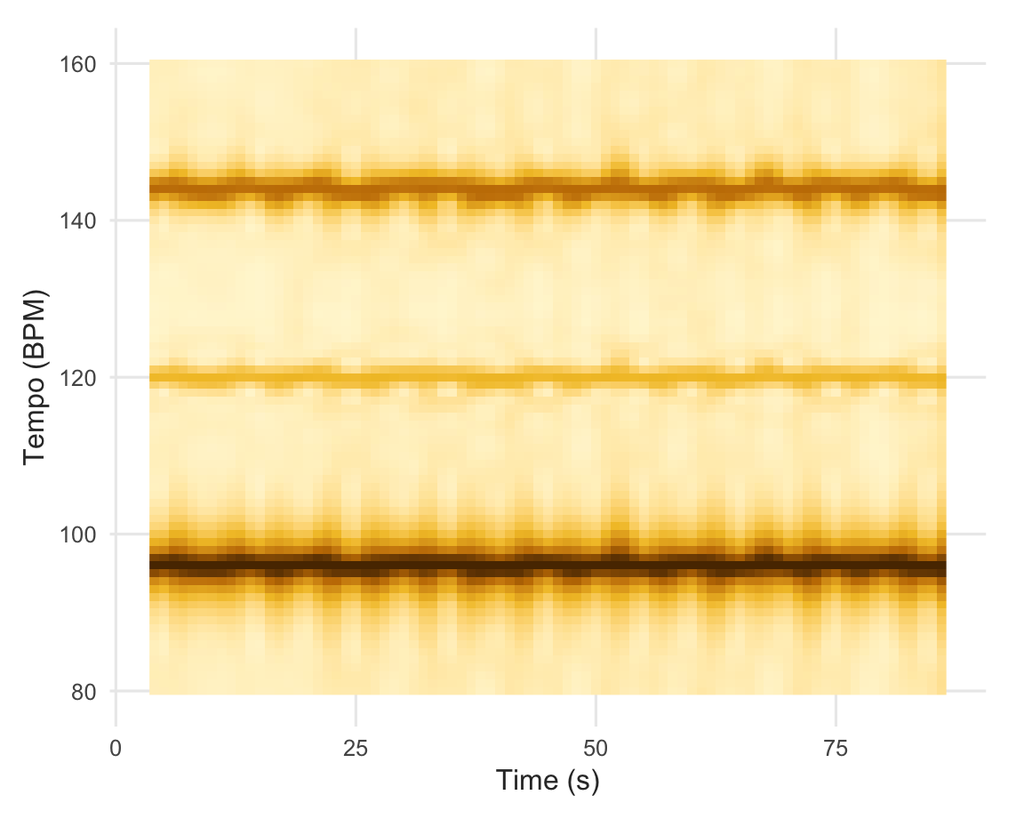

> The tempogram comparison reveals a clear difference in rhythmic consistency between the two tracks. Track 1 exhibits a stable tempo across its duration, with two dominant bands around 95 BPM and 140 BPM. This suggests a layered, polyrhythmic feel that enhances its groove and danceability.

### Track 2: Chromagram

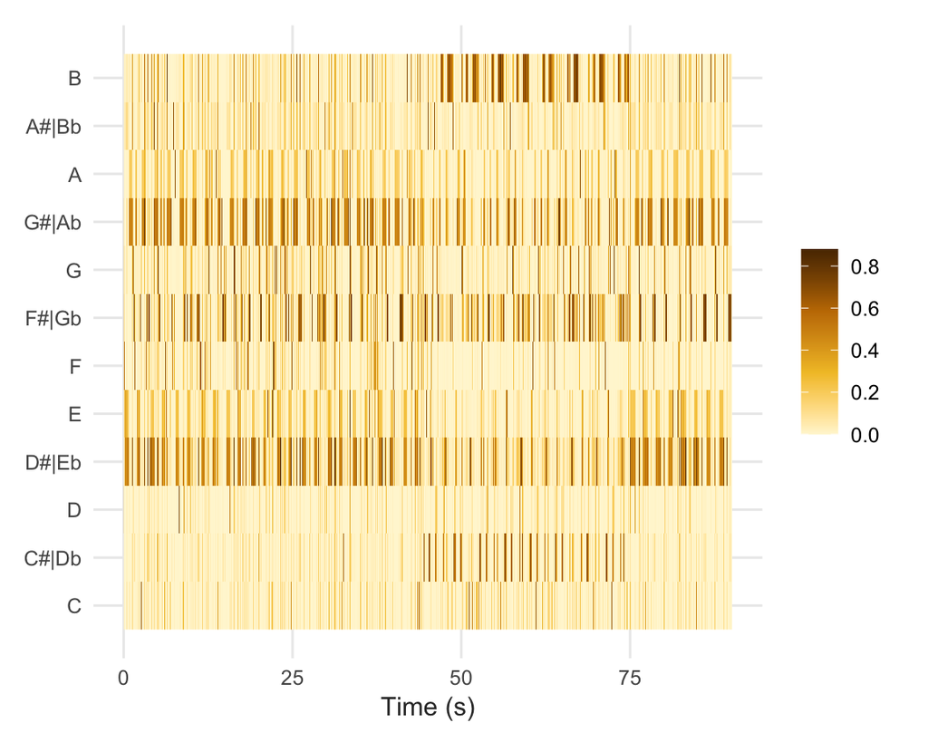

> Compared to Track 1, this track shows more harmonic variation but less repetition. It might be more expressive or fluid, but less predictable, which may slightly reduce its danceability.

### Cepstrogram

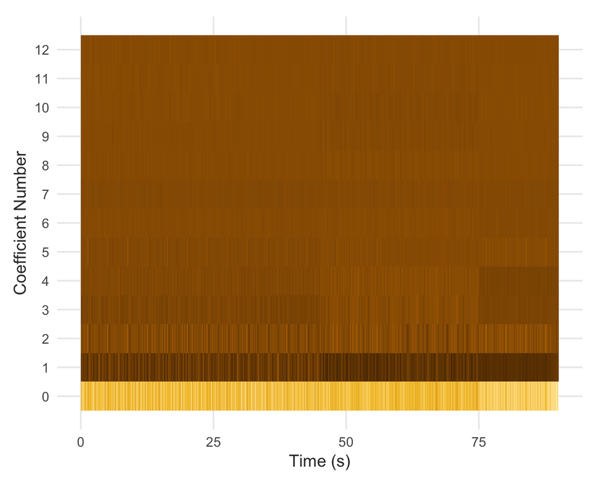

> In contrast, Track 2 exhibits more activity in the mid-level MFCCs (especially coefficients 4–6), indicating greater timbral variation across time. While this variation may add sonic interest and subtle rhythmic motion, it could also disrupt the regularity needed for a strong danceable groove. Overall, the more homogeneous timbre of Track 1 might contribute to stronger perceived danceability, whereas Track 2’s textural complexity could either enhance or interfere with it depending on how listeners interpret the changes.

### Chroma-based

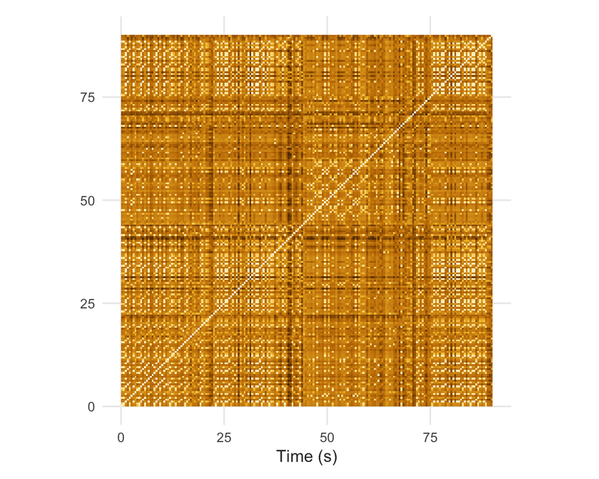

> Track 2, in contrast, shows a more varied and diffuse similarity structure. While there are some repeated harmonic segments, the overall pattern is less consistent. This may reflect expressive variation or structural shifts that reduce rhythmic predictability and, in turn, slightly weaken the groove.

### Timbre-based

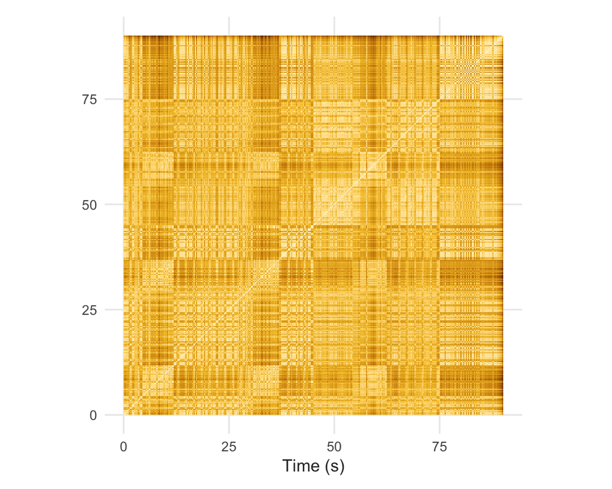

> Track 2, on the other hand, presents a more fragmented and intricate similarity pattern. The lack of strongly defined repeating sections suggests continuous timbral variation, which may offer richness and expressiveness but potentially disrupts the consistency needed for strong perceived danceability.

### Chordogram

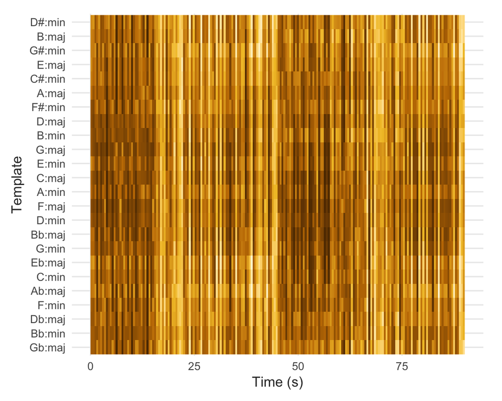

### Tempogram

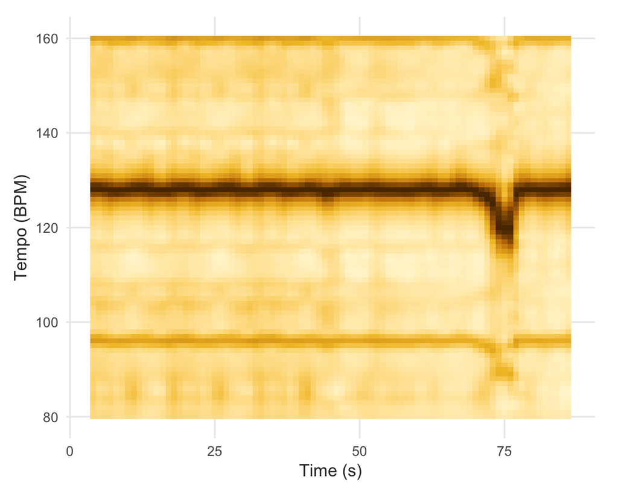

> Track 2 shows a more singular dominant tempo around 130 BPM, but it undergoes a noticeable disruption near the 75-second mark. This break in rhythmic flow might interfere with its groove and reduce the sense of momentum, potentially contributing to its lower danceability score.

# Conclusion

### Finding 1: Tempo is not the main driver

63 BPM tempo of the most danceable track (roemer-i-2)

100 of 108 tracks in the corpus are faster than it

**Tempo alone does not determine danceability.** The five most danceable tracks are on average *slower* than the corpus mean, while the five least danceable are *faster*.

### Finding 2: Emotional features matter more

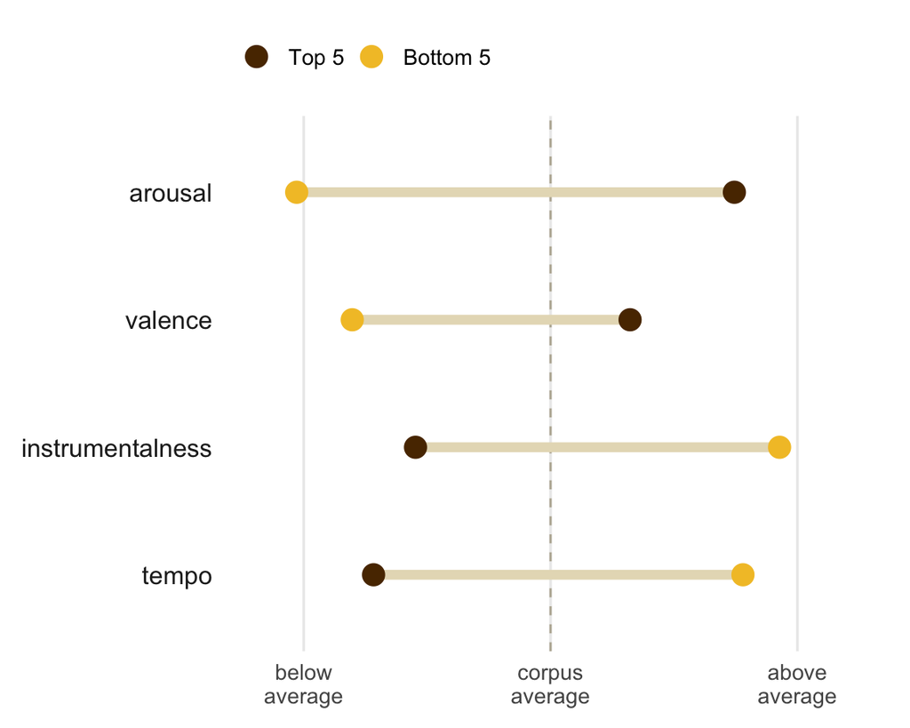

> Average standardised feature values of the five most and five least danceable tracks. The most danceable tracks score **higher on arousal and valence** and **lower on instrumentalness** (more vocal presence), and they are slower, not faster.

### Finding 3: Structure matters

My two tracks, compared on the track-level plots:

|  | Track 1 | Track 2 |
| --- | --- | --- |
| Danceability | **0.85** | **0.72** |
| Harmony (chroma SSM) | Regular, grid-like repetition | More varied, diffuse |
| Timbre (MFCC SSM) | Large repeated blocks | Fragmented |
| Tempo (tempogram) | Stable bands at ~95 and ~140 BPM | ~130 BPM, break near 75 s |

The more danceable track shows **clearer repetition** and **steadier rhythm**, structure that summary features alone do not capture.